# DEM 5283/7283 Week 4: Comparing Nested Logit Models, and Logits for Prediction

Statistics for Demographic Data II

Author

Corey S. Sparks, PhD

Published

October 22, 2026

## Introduction

Last week we fit logit and probit models and turned the coefficients into odds ratios, predicted probabilities and average marginal effects. This week has two parts, and they pull in different directions.

The first part is about explanation. Demographers love nested models: enter race and ethnicity, then add education and income, and see how much the race coefficients shrink. It’s how a lot of the literature on health disparities is written. But in a logit model that comparison isn’t as simple as it looks, because the coefficients from the two models are on different scales. I’ll show why, and then show two fixes: the KHB method and average marginal effects.

The second part is about prediction. Here we don’t care much about any one coefficient, we care about how well the model sorts people it has never seen. That calls for different tools (training and test data, cross-validation, thresholds and calibration), and I’ll use the `tidymodels` framework for them (Kuhn and Silge 2022).

## Setup

```r
library(tidyverse)
library(here)
library(survey)
library(marginaleffects)
library(modelsummary)
library(tidymodels)
library(probably)
library(sparkscolors)

source(here("R", "get_mmsa.R"))
source(here("R", "recode_mmsa.R"))
source(here("R", "get_dhs_model.R"))
```

## Part 1: Comparing nested logit models

### The data and the question

In a research setting we are almost never satisfied with a single, solitary model. The literature on most subjects has several facets, and we want to know how they fit together. A classic example is whether socioeconomic status accounts for racial and ethnic differences in health. Hummer (1993) asked it about infant mortality, Sudano and Baker (2006) about health declines and mortality in late middle age, and Shuey and Willson (2008) about health trajectories over the life course. Analyses like these enter predictors in **blocks**:

$$\begin{aligned}
\text{Model 1:}\quad & \text{logit}(\pi) = \beta_0 + \text{race/ethnicity} + \text{age} + \text{sex} \\
\text{Model 2:}\quad & \text{logit}(\pi) = \beta_0 + \text{race/ethnicity} + \text{age} + \text{sex} + \text{SES} \\
\text{Model 3:}\quad & \text{logit}(\pi) = \beta_0 + \text{race/ethnicity} + \text{age} + \text{sex} + \text{SES} + \text{health behaviors}
\end{aligned}$$

and then watch what happens to the race and ethnicity coefficients from one block to the next. When an effect gets smaller after we control for something, the fancy word is that it has been *attenuated*.

I’ll use the 2024 BRFSS SMART MMSA data with the standard recodes from week 2 (they live in `R/recode_mmsa.R` now). The question is the classic one: how much of the difference in fair or poor self-rated health across racial and ethnic groups is associated with differences in education and income, and what changes when we add smoking and health insurance?

```r
brfss <- get_mmsa(2024) |>
  recode_mmsa() |>
  mutate(complete = complete.cases(badhealth, race_eth, agec, female, educ, income,
                                   smoke, insured))

des <- svydesign(ids = ~1, strata = ~ststr, weights = ~mmsawt, data = brfss)
des_cc <- subset(des, complete)
```

Nested models have to be fit to the same respondents, or the comparison is meaningless. Income is missing for 19.5% of respondents (the BRFSS income question has a lot of “don’t know” and “refused” answers), and smoking and insurance add a little more missingness, so I restrict all three models to the 73.7% of respondents with complete data, using `subset()`. Throwing away a quarter of the sample is not something I’d do in a paper, and in week 9 we’ll impute those values instead.

### The usual approach

Model 1 has race and ethnicity plus age and sex. Model 2 adds education and income. Model 3 adds smoking status and health insurance coverage.

```r
m1 <- svyglm(badhealth ~ race_eth + agec + female,
             design = des_cc, family = quasibinomial())
m2 <- svyglm(badhealth ~ race_eth + agec + female + educ + income,
             design = des_cc, family = quasibinomial())
m3 <- svyglm(badhealth ~ race_eth + agec + female + educ + income + smoke + insured,
             design = des_cc, family = quasibinomial())

modelsummary(list("Model 1" = m1, "Model 2" = m2, "Model 3" = m3),
             coef_omit = "agec|female|Intercept",
             coef_rename = \(x) str_remove_all(x, "race_eth|educ|income|smoke"),
             gof_map = "nobs", fmt = 3,
             title = "Logit coefficients for fair or poor health")
```

Logit coefficients for fair or poor health

|  | Model 1 | Model 2 | Model 3 |
| --- | --- | --- | --- |
| NH Black | 0.377 | 0.053 | 0.117 |
|  | (0.041) | (0.043) | (0.043) |
| NH Other | 0.069 | 0.039 | 0.103 |
|  | (0.066) | (0.069) | (0.069) |
| NH Multiracial | 0.406 | 0.223 | 0.213 |
|  | (0.075) | (0.078) | (0.078) |
| Hispanic | 0.787 | 0.130 | 0.220 |
|  | (0.038) | (0.045) | (0.046) |
| HS graduate |  | -0.449 | -0.430 |
|  |  | (0.056) | (0.056) |
| Some college |  | -0.512 | -0.480 |
|  |  | (0.057) | (0.057) |
| College graduate |  | -0.981 | -0.886 |
|  |  | (0.058) | (0.058) |
| $25k-$50k |  | -0.552 | -0.539 |
|  |  | (0.042) | (0.042) |
| $50k-$100k |  | -1.055 | -1.025 |
|  |  | (0.045) | (0.045) |
| $100k+ |  | -1.626 | -1.568 |
|  |  | (0.051) | (0.051) |
| Former |  |  | 0.364 |
|  |  |  | (0.035) |
| Current |  |  | 0.546 |
|  |  |  | (0.044) |
| insured |  |  | -0.029 |
|  |  |  | (0.057) |
| Num.Obs. | 169945 | 169945 | 169945 |

I use `quasibinomial()` here because it gives the same estimates as `binomial()` without the warning about non-integer successes that survey weights cause. The block of SES variables clearly matters, and a design-based Wald test says so:

```r
regTermTest(m2, ~ educ + income, method = "Wald")
```

```
Wald test for educ income
 in svyglm(formula = badhealth ~ race_eth + agec + female + educ +
    income, design = des_cc, family = quasibinomial())
F =  390.0396  on  6  and  168752  df: p= < 2.22e-16
```

Model 3 is where it gets interesting. Adding health behaviors, the Hispanic coefficient goes back *up*, from 0.13 to 0.22, and the Black coefficient goes from 0.053 to 0.117. This is somewhat confusing at first, but it’s most likely about differences in smoking. Hispanic and Black adults in these data smoke less than non-Hispanic White adults with the same education and income, so smoking was hiding part of their disadvantage in Model 2. Once we compare people with the same smoking history, the gap opens back up. That’s a **suppression** effect, the mirror image of attenuation. Current smokers have 1.73 times the odds of fair or poor health of people who never smoked, while insurance coverage has no detectable association with the outcome once everything else is in the model (p = 0.61).

### Comparing model fit

There are several ways to ask whether a bigger model explains the outcome better than a smaller one, and for nested models we’re usually asking whether the new block was worth adding. The `regTermTest()` Wald test above is one. In an ordinary `glm()`, the traditional way is a likelihood ratio test, but with survey weights the “likelihood” is a weighted pseudo-likelihood, and the usual likelihood ratio statistic doesn’t have a $\chi^2$ distribution. `anova()` on two `svyglm()` models does the right thing, a Rao-Scott working likelihood ratio test that corrects for the design (Lumley and Scott 2014):

```r
anova(m1, m2)
```

```
Working (Rao-Scott+F) LRT for educ income
 in svyglm(formula = badhealth ~ race_eth + agec + female + educ +
    income, design = des_cc, family = quasibinomial())
Working 2logLR =  2396.486 p= < 2.22e-16
(scale factors:  1.3 1.1 1 0.97 0.92 0.7 );  denominator df= 168752
```

```r
anova(m2, m3)
```

```
Working (Rao-Scott+F) LRT for smoke insured
 in svyglm(formula = badhealth ~ race_eth + agec + female + educ +
    income + smoke + insured, design = des_cc, family = quasibinomial())
Working 2logLR =  187.3072 p= < 2.22e-16
(scale factors:  1.2 0.95 0.89 );  denominator df= 168749
```

Both blocks significantly improve the fit. The **Akaike information criterion** is the other common tool. It has two parts, a measure of how badly the model fits (the deviance) and a penalty for the number of parameters $k$:

$$AIC = -2 \log L(\hat\theta) + 2k$$

Lower is better, and you can only compare AICs for models fit to exactly the same data, which is one more reason the three models share a sample. A naive AIC computed from the weighted pseudo-likelihood isn’t valid, but `AIC()` on a `svyglm()` model gives the design-based version of Lumley and Scott (2015), which replaces the $2k$ penalty with one based on the design effects (the `eff.p` column is the effective number of parameters):

```r
AIC(m1, m2, m3)
```

```
        eff.p      AIC deltabar
[1,] 51.17661 154763.6 5.117661
[2,] 80.68696 143068.0 5.042935
[3,] 95.22054 142153.1 5.011607
```

Model 3 has the lowest AIC by a wide margin. A common rule of thumb is that if two models are within about 10 AIC points of each other, you should prefer the more parsimonious one. That isn’t an issue here, but with smaller samples or weaker blocks it often is.

The traditional reading goes like this. The Hispanic coefficient falls from 0.787 to 0.13 once we control for education and income, so SES “explains” about 84% of the Hispanic disadvantage in self-rated health. Similar stories for the other groups. That’s the kind of sentence that ends up in a lot of abstracts. The problem is that the two coefficients aren’t measured in the same units.

### Why logit coefficients from nested models aren’t comparable

A logit model can be written as a model for an unobserved, continuous propensity $y^*$:

$$y^*_i = \beta_0 + \beta_1 x_i + \varepsilon_i, \qquad y_i = 1 \text{ if } y^*_i > 0$$

We never see $y^*$, so its scale is arbitrary, and the logit model pins it down by fixing the variance of $\varepsilon$ at $\pi^2/3$. What we actually estimate is $\beta_1 / \sigma$, the coefficient divided by the standard deviation of the error. When we add a predictor that explains some of $y^*$, the true error variance shrinks, the model rescales everything so the error variance is $\pi^2/3$ again, and every coefficient gets bigger, *even if the new predictor has nothing to do with $x$* (Mood 2010; Breen et al. 2018).

A quick simulation shows it. Here `z` is generated independently of `x`, so adding it to the model should change nothing about the effect of `x`.

```r
set.seed(7283)
n <- 100000
sim <- tibble(x = rnorm(n),
              z = rnorm(n),
              y = rbinom(n, 1, plogis(1 * x + 2 * z)))

c(without_z = coef(glm(y ~ x, data = sim, family = binomial))[["x"]],
  with_z = coef(glm(y ~ x + z, data = sim, family = binomial))[["x"]])
```

```
without_z    with_z
0.6179576 1.0057877
```

The true coefficient on `x` is 1. Leave out `z` and we estimate about 0.6, and that has nothing to do with confounding, because `z` is unrelated to `x`. It’s purely rescaling. In a nested comparison like ours, the change in the race coefficient between Model 1 and Model 2 mixes two things: the real confounding (or mediation) by SES, which we want, and this rescaling, which we don’t. The rescaling works *against* finding attenuation, so naive comparisons tend to understate how much the SES variables account for.

### The KHB method

Karlson et al. (2012) proposed a fix that is simple once you see it. The trouble is that Model 1 and Model 2 explain different amounts of the variance in $y^*$. So build a version of Model 1 that explains exactly as much as Model 2 does. Take each SES variable, regress it on the race and control variables, and keep the residuals. The residuals carry all the information in the SES variables *except* the part that overlaps with race. Put them in Model 1 in place of the SES variables, and now the “reduced” model and the full model have the same fit and the same scale, but the race coefficient in the reduced model still hasn’t been adjusted for SES.

There’s a `khb` command in Stata, but I’m not aware of a maintained R package, and it only takes a few lines to do by hand.

```r
cc <- brfss |> filter(complete)

# SES dummies, and the design matrix for race and the controls
Z <- model.matrix(~ educ + income, data = cc)[, -1]
X <- model.matrix(~ race_eth + agec + female, data = cc)

# residualize each SES dummy on X, using the survey weights
Z_resid <- apply(Z, 2, \(z) resid(lm.wfit(X, z, w = cc$mmsawt)))
colnames(Z_resid) <- paste0("r_", make.names(colnames(Z)))

brfss_khb <- brfss
brfss_khb[colnames(Z_resid)] <- NA_real_
brfss_khb[brfss_khb$complete, colnames(Z_resid)] <- Z_resid

des_khb <- svydesign(ids = ~1, strata = ~ststr, weights = ~mmsawt,
                     data = brfss_khb) |>
  subset(complete)

f_khb <- reformulate(c("race_eth", "agec", "female", colnames(Z_resid)),
                     response = "badhealth")
m1_khb <- svyglm(f_khb, design = des_khb, family = quasibinomial())
```

```r
khb_tab <- naive |>
  mutate(m1_khb = coef(m1_khb)[re],
         change_khb = (m1_khb - m2) / m1_khb,
         rescaling = m1_khb / m1)

khb_tab |>
  select(term,
         `Model 1 (naive)` = m1,
         `Model 1 (KHB)` = m1_khb,
         `Model 2` = m2,
         `Change, naive` = change,
         `Change, KHB` = change_khb) |>
  knitr::kable(digits = 3)
```

| term | Model 1 (naive) | Model 1 (KHB) | Model 2 | Change, naive | Change, KHB |
| --- | --- | --- | --- | --- | --- |
| NH Black | 0.377 | 0.382 | 0.053 | 0.859 | 0.860 |
| NH Other | 0.069 | 0.052 | 0.039 | 0.439 | 0.260 |
| NH Multiracial | 0.406 | 0.413 | 0.223 | 0.450 | 0.460 |
| Hispanic | 0.787 | 0.791 | 0.130 | 0.835 | 0.836 |

**Note**

KHB standard errors for the difference need a delta-method calculation, which the Stata command does for you. In R, the most direct route is to repeat the calculation over replicate weights (`as.svrepdesign()`, from week 2) and use the spread of the differences. Exercise 2 asks you to do this for a smaller sample.

### Average marginal effects

The other fix is to stop comparing log-odds altogether. Average marginal effects (AMEs) are differences in predicted probabilities, averaged over the sample, and probabilities have the same scale in every model (Mood 2010). The `marginaleffects` package computes them for `svyglm()` models, with the survey weights used in the averaging.

```r
ame <- list("Model 1" = m1, "Model 2" = m2) |>
  map(\(m) avg_comparisons(m, variables = "race_eth", wts = "(weights)")) |>
  map(as_tibble) |>
  list_rbind(names_to = "model") |>
  mutate(contrast = str_remove(contrast, " - NH White"))

ame |>
  select(model, contrast, estimate, std.error, conf.low, conf.high) |>
  knitr::kable(digits = 3)
```

| model | contrast | estimate | std.error | conf.low | conf.high |
| --- | --- | --- | --- | --- | --- |
| Model 1 | Hispanic | 0.124 | 0.007 | 0.110 | 0.137 |
| Model 1 | NH Black | 0.052 | 0.006 | 0.040 | 0.064 |
| Model 1 | NH Multiracial | 0.057 | 0.012 | 0.034 | 0.080 |
| Model 1 | NH Other | 0.009 | 0.008 | -0.008 | 0.025 |
| Model 2 | Hispanic | 0.017 | 0.006 | 0.005 | 0.029 |
| Model 2 | NH Black | 0.007 | 0.006 | -0.004 | 0.018 |
| Model 2 | NH Multiracial | 0.030 | 0.011 | 0.009 | 0.052 |
| Model 2 | NH Other | 0.005 | 0.009 | -0.013 | 0.023 |

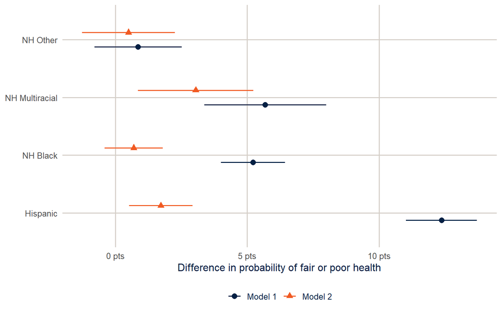

Figure 1: Average marginal effects of race and ethnicity on the probability of fair or poor health, relative to non-Hispanic White adults, before and after adjusting for education and income.

```r
ame |>
  ggplot(aes(x = estimate, y = contrast, colour = model, shape = model)) +
  geom_vline(xintercept = 0, colour = utsa_cols("smoke")) +
  geom_pointrange(aes(xmin = conf.low, xmax = conf.high),
                  position = position_dodge(width = 0.5)) +
  scale_colour_utsa(palette = "primary") +
  scale_x_continuous(labels = scales::label_number(scale = 100, suffix = " pts")) +
  labs(x = "Difference in probability of fair or poor health", y = NULL,
       colour = NULL, shape = NULL)
```

Now the result reads in percentage points, which is what most readers think in anyway. Before adjusting for SES, Hispanic adults are 12.4 percentage points more likely than non-Hispanic White adults to report fair or poor health. After adjustment the gap is 1.7 points. I’d report the AMEs next to (or in place of) the odds ratios in a paper, and I’ll expect them in yours.

### Stratified models

You’ll often see models in the literature **stratified** by some predictor, fit separately for men and women, say, or for each racial and ethnic group. This is usually because the hypothesis is that the effect of one variable differs across the groups. Does education protect everyone’s health equally, or does it pay off more for some groups than others?

The first thing to do is test the interaction. If the education by race interaction isn’t significant, we have no justification for stratifying, because the data don’t tell us the effect of education varies by race. This is the test of parallel slopes from the analysis of covariance.

```r
m_int <- svyglm(badhealth ~ race_eth * educ + agec + female + income + smoke + insured,
                design = des_cc, family = quasibinomial())
regTermTest(m_int, ~ race_eth:educ, method = "Wald")
```

```
Wald test for race_eth:educ
 in svyglm(formula = badhealth ~ race_eth * educ + agec + female +
    income + smoke + insured, design = des_cc, family = quasibinomial())
F =  2.359678  on  12  and  168737  df: p= 0.0049746
```

The interaction test gives p = 0.005, so there is evidence that the education gradient isn’t the same in every group. Now we can stratify. I fit the model separately for non-Hispanic White, non-Hispanic Black and Hispanic adults by subsetting the design.

```r
groups <- c("NH White", "NH Black", "Hispanic")

strat <- groups |>
  set_names() |>
  map(\(g) svyglm(badhealth ~ educ + agec + female + income + smoke + insured,
                  design = subset(des_cc, race_eth == g),
                  family = quasibinomial()))

modelsummary(strat, coef_omit = "agec|Intercept",
             coef_rename = \(x) str_remove_all(x, "educ|income|smoke"),
             gof_map = "nobs", fmt = 3,
             title = "Logit coefficients for fair or poor health, stratified by race and ethnicity")
```

Logit coefficients for fair or poor health, stratified by race and ethnicity

|  | NH White | NH Black | Hispanic |
| --- | --- | --- | --- |
| HS graduate | -0.540 | -0.127 | -0.378 |
|  | (0.080) | (0.146) | (0.092) |
| Some college | -0.525 | -0.294 | -0.508 |
|  | (0.079) | (0.147) | (0.105) |
| College graduate | -0.977 | -0.453 | -0.964 |
|  | (0.081) | (0.158) | (0.111) |
| female | 0.001 | 0.185 | 0.039 |
|  | (0.034) | (0.077) | (0.074) |
| $25k-$50k | -0.607 | -0.582 | -0.482 |
|  | (0.053) | (0.101) | (0.084) |
| $50k-$100k | -1.201 | -1.068 | -0.779 |
|  | (0.052) | (0.107) | (0.111) |
| $100k+ | -1.730 | -1.562 | -1.315 |
|  | (0.060) | (0.136) | (0.137) |
| Former | 0.401 | 0.418 | 0.252 |
|  | (0.038) | (0.109) | (0.096) |
| Current | 0.635 | 0.494 | 0.387 |
|  | (0.050) | (0.105) | (0.118) |
| insured | 0.107 | -0.100 | -0.164 |
|  | (0.081) | (0.175) | (0.089) |
| Num.Obs. | 120125 | 16903 | 21332 |

To test whether one coefficient is the same in two separate models $j$ and $k$, the classic approach (Allison 1999) is a $z$ test built from the two coefficients and their standard errors, which works because the two groups are independent subsamples:

$$z = \frac{\beta_{j} - \beta_{k}}{\sqrt{\left[s.e.(\beta_{j})\right]^2 + \left[s.e.(\beta_{k})\right]^2}}$$

```r
z_test <- function(m_j, m_k, term) {
  d <- coef(m_j)[[term]] - coef(m_k)[[term]]
  se <- sqrt(SE(m_j)[[term]]^2 + SE(m_k)[[term]]^2)
  tibble(term = term, difference = d, z = d / se, p = 2 * pnorm(-abs(d / se)))
}

bind_rows(z_test(strat[["Hispanic"]], strat[["NH White"]], "educCollege graduate"),
          z_test(strat[["NH Black"]], strat[["NH White"]], "educCollege graduate"))
```

```
# A tibble: 2 × 4
  term                 difference      z       p
  <chr>                     <dbl>  <dbl>   <dbl>
1 educCollege graduate     0.0132 0.0964 0.923
2 educCollege graduate     0.524  2.96   0.00306
```

The college coefficient for Hispanic adults isn’t significantly different from the one for non-Hispanic White adults (p = 0.92). The one for Black adults is less negative, and the difference is significant (p = 0.0031), which would usually be read as a college degree being associated with a smaller health advantage for Black adults than for White adults. That’s a finding with a real literature behind it, often discussed as “diminished returns” to education. But here’s the catch, which brings us back to the scaling problem.

### Comparing effects across groups

The same scaling problem shows up when you compare a coefficient across groups, for example the education gradient for men versus women in separate models. If the residual variance differs between the groups, the logit coefficients differ even when the underlying effects don’t (Allison 1999). AMEs sidestep this too. Here I fit the model separately for men and women and compare the AME of a college degree (versus a high school diploma) on the probability scale.

```r
educ_ame <- c(Men = 0, Women = 1) |>
  map(\(s) svyglm(badhealth ~ educ + race_eth + agec,
                  design = subset(des, female == s),
                  family = quasibinomial())) |>
  map(\(m) avg_comparisons(m, wts = "(weights)",
                           variables = list(educ = c("HS graduate", "College graduate")))) |>
  map(as_tibble) |>
  list_rbind(names_to = "sex")

educ_ame |> select(sex, estimate, std.error, conf.low, conf.high) |>
  knitr::kable(digits = 3)
```

| sex | estimate | std.error | conf.low | conf.high |
| --- | --- | --- | --- | --- |
| Men | -0.118 | 0.006 | -0.130 | -0.107 |
| Women | -0.129 | 0.006 | -0.141 | -0.117 |

Men and women are separate subsamples, so the difference between the two AMEs has a standard error of roughly $\sqrt{SE_1^2 + SE_2^2}$:

```r
educ_ame |>
  summarise(difference = diff(estimate),
            se = sqrt(sum(std.error^2))) |>
  mutate(z = difference / se,
         p = 2 * pnorm(-abs(z)))
```

```
# A tibble: 1 × 4
  difference      se     z     p
       <dbl>   <dbl> <dbl> <dbl>
1    -0.0107 0.00839 -1.27 0.204
```

Compared with a high school diploma, a college degree goes with a probability of fair or poor health that is 11.8 points lower for men and 12.9 points lower for women. The difference between the two is small and not statistically significant, and because both are on the probability scale, that comparison means what it says.

## Part 2: Logistic regression for prediction

### Explanation versus prediction

Everything so far has been about the coefficients. In prediction we flip that around. The question is how well a model sorts *new* cases into the right category, and a model can predict well with coefficients that mean nothing causally, or predict badly with coefficients that are perfectly good estimates. Demographers do more prediction than we sometimes admit: imputing missing values, building propensity scores (week 14) and flagging likely nonrespondents all depend on it.

The key rule is that you judge a predictive model on data it wasn’t fit to. A model always looks better on its own training data, and how much better depends on how flexible it is.

### The data

For this part I’ll use the DHS model dataset. It looks like a real Demographic and Health Survey but describes no real country, so it’s free to use. The outcome is whether a woman currently uses a modern contraceptive method, among women who are sexually active and not pregnant.

```r
dhs <- get_dhs_model() |>
  filter(v213 == 0, v536 %in% 1:3) |>
  mutate(modern = factor(if_else(v313 == 3, "yes", "no"), levels = c("yes", "no")),
         age = v012,
         children = v218,
         educ = factor(v106, 0:3, c("None", "Primary", "Secondary", "Higher")),
         wealth = factor(v190, 1:5, c("Poorest", "Poorer", "Middle", "Richer", "Richest")),
         rural = factor(v025, 1:2, c("Urban", "Rural")),
         region = factor(v024)) |>
  select(modern, age, children, educ, wealth, rural, region)

count(dhs, modern) |> mutate(share = n / sum(n))
```

```
# A tibble: 2 × 3
  modern     n share
  <fct>  <int> <dbl>
1 yes     1761 0.259
2 no      5044 0.741
```

I put “yes” first because `yardstick` treats the first factor level as the event of interest. I’m also ignoring the survey design in this part. That’s common in prediction work, because the goal is to sort individuals, not to estimate a population quantity. But if you want performance measures that describe the *population* (say, sensitivity among all women in the country), you’d use the weights, and `tidymodels` supports case weights for that.

### Training and test data

`initial_split()` holds out 20% of the data as a test set that we won’t touch until the very end. Stratifying the split on the outcome keeps the share of modern method users the same in both pieces.

```r
set.seed(7283)
dhs_split <- initial_split(dhs, prop = 0.8, strata = modern)
dhs_train <- training(dhs_split)
dhs_test <- testing(dhs_split)
```

### A recipe and a workflow

The model itself is the familiar logit:

$$\log\left(\frac{\Pr(\text{modern method})}{1 - \Pr(\text{modern method})}\right) = \mathbf{x}'\boldsymbol\beta
\quad\Longleftrightarrow\quad
\Pr(\text{modern method}) = \frac{1}{1 + \exp(-\mathbf{x}'\boldsymbol\beta)}$$

What’s new is how we use it. Instead of reading the coefficients, we take each woman’s predicted probability and turn it into a predicted class.

A **recipe** describes the preprocessing (dummy variables, a quadratic for age), a **model specification** says what kind of model to fit, and a **workflow** bundles the two so the same steps get applied to every piece of data.

```r
dhs_recipe <- recipe(modern ~ ., data = dhs_train) |>
  step_dummy(all_nominal_predictors()) |>
  step_poly(age, degree = 2)

logit_wf <- workflow(dhs_recipe, logistic_reg())
```

### Cross-validation

To get an honest estimate of performance without touching the test set, we use 10-fold cross-validation on the training data. The data are split into 10 pieces, and the model is fit 10 times, each time on 9 pieces and evaluated on the one left out.

```r
dhs_folds <- vfold_cv(dhs_train, v = 10, strata = modern)

dhs_metrics <- metric_set(roc_auc, brier_class, accuracy, sensitivity, specificity)

logit_cv <- fit_resamples(logit_wf, resamples = dhs_folds, metrics = dhs_metrics,
                          control = control_resamples(save_pred = TRUE))

collect_metrics(logit_cv)
```

```
# A tibble: 5 × 6
  .metric     .estimator  mean     n std_err .config
  <chr>       <chr>      <dbl> <int>   <dbl> <chr>
1 accuracy    binary     0.746    10 0.00388 pre0_mod0_post0
2 brier_class binary     0.172    10 0.00169 pre0_mod0_post0
3 roc_auc     binary     0.711    10 0.00686 pre0_mod0_post0
4 sensitivity binary     0.231    10 0.00686 pre0_mod0_post0
5 specificity binary     0.925    10 0.00533 pre0_mod0_post0
```

These metrics measure different things:

- **Accuracy** is the share classified correctly at a threshold of 0.5.
- **Sensitivity** is the share of modern method users the model catches.
- **Specificity** is the share of non-users it correctly leaves alone.
- **The area under the ROC curve (AUC)** is the probability that a randomly chosen user gets a higher predicted probability than a randomly chosen non-user. It doesn’t depend on any threshold.
- **The Brier score** is the mean squared difference between the predicted probability and the 0/1 outcome, so lower is better.

Here is the humbling part. Accuracy is 74.6%, which sounds fine until you notice that only 25.9% of women use a modern method. A “model” that predicts “no” for everyone would be right 74.1% of the time. Our model barely beats that, and its sensitivity is 23.1%, so it misses most users. The AUC of 0.71 says the model does carry real information. The 0.5 threshold is just a bad way to use it when the outcome is this uncommon.

### Decision rules and the confusion matrix

It helps to see where those numbers come from. The model gives each woman a probability. To turn probabilities into classes, we need a **decision rule**: a threshold, so that a woman is classified as a modern method user if $\Pr(y = \text{modern} \mid \mathbf{x}) > c$, and as a non-user otherwise. The default is $c = 0.5$. Cross-tabulating the observed classes against the predicted ones gives the **confusion matrix**.

```r
cv_class <- collect_predictions(logit_cv) |>
  mutate(pred_05 = factor(if_else(.pred_yes > 0.5, "yes", "no"), levels = c("yes", "no")),
         pred_mean = factor(if_else(.pred_yes > base_rate, "yes", "no"),
                            levels = c("yes", "no")))

conf_mat(cv_class, truth = modern, estimate = pred_05)
```

```
          Truth
Prediction  yes   no
       yes  325  301
       no  1083 3734
```

The columns are the truth and the rows are the predictions. The diagonal holds the women the model gets right, the **true positives** (users predicted to be users) and **true negatives** (non-users predicted to be non-users). The off-diagonal cells are the mistakes: **false positives**, non-users the model calls users, and **false negatives**, users it misses. Accuracy is the diagonal divided by the total. Sensitivity is the true positives divided by all actual users (the first column), and specificity is the true negatives divided by all actual non-users (the second column). With the 0.5 rule, most of the users end up in the false negative cell.

A simple alternative is to use the mean of the outcome as the threshold, calling a woman a likely user if her predicted probability is higher than the share of users in the training data.

```r
conf_mat(cv_class, truth = modern, estimate = pred_mean)
```

```
          Truth
Prediction  yes   no
       yes  886 1220
       no   522 2815
```

```r
bind_rows(
  "Threshold 0.5" = metric_set(accuracy, sensitivity, specificity)(cv_class, truth = modern,
                                                                   estimate = pred_05),
  "Threshold = mean" = metric_set(accuracy, sensitivity, specificity)(cv_class, truth = modern,
                                                                      estimate = pred_mean),
  .id = "rule") |>
  select(rule, .metric, .estimate) |>
  pivot_wider(names_from = .metric, values_from = .estimate)
```

```
# A tibble: 2 × 4
  rule             accuracy sensitivity specificity
  <chr>               <dbl>       <dbl>       <dbl>
1 Threshold 0.5       0.746       0.231       0.925
2 Threshold = mean    0.680       0.629       0.698
```

Lowering the threshold trades specificity for sensitivity. The model now catches far more of the users, at the cost of flagging more non-users, and overall accuracy falls. Which rule is better depends entirely on what the predictions are for.

### Choosing a threshold

The threshold is a decision, not a statistical result, and it should reflect what the two kinds of error cost. A program trying to reach every woman with an unmet need for family planning might accept a lot of false positives to avoid missing anyone. `probably::threshold_perf()` shows the tradeoff using the cross-validated predictions.

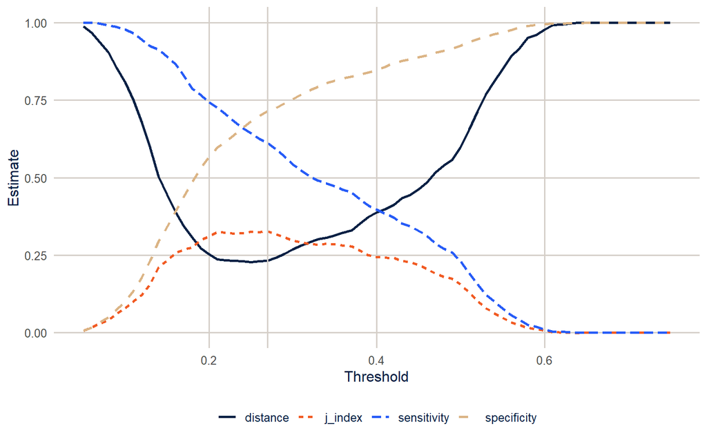

Figure 2: Cross-validated sensitivity and specificity across classification thresholds. Youden’s J is their sum minus one.

```r
cv_preds <- collect_predictions(logit_cv)

thresholds <- threshold_perf(cv_preds, modern, .pred_yes,
                             thresholds = seq(0.05, 0.75, by = 0.01),
                             metrics = metric_set(sensitivity, specificity, j_index))

best_j <- thresholds |>
  filter(.metric == "j_index") |>
  slice_max(.estimate, n = 1, with_ties = FALSE)

thresholds |>
  ggplot(aes(x = .threshold, y = .estimate, colour = .metric, linetype = .metric)) +
  geom_line(linewidth = 1) +
  geom_vline(xintercept = best_j$.threshold, colour = utsa_cols("smoke")) +
  scale_colour_utsa() +
  labs(x = "Threshold", y = "Estimate", colour = NULL, linetype = NULL)
```

Youden’s J, which weights sensitivity and specificity equally, peaks at a threshold of 0.27. That’s close to the share of users in the data, which is a common and sensible starting point when the outcome is uncommon.

### Calibration

A model can rank people well and still get the probabilities wrong. **Calibration** asks whether, among women with a predicted probability around 0.3, about 30% actually use a modern method. If the predicted probabilities are going to be used as probabilities (as risk scores, or in propensity score weights in week 14), calibration matters as much as discrimination.

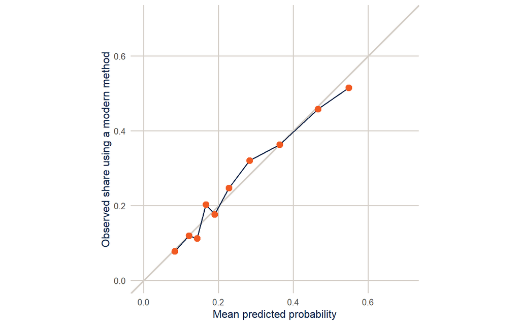

Figure 3: Calibration of the cross-validated predictions. Points are deciles of predicted probability; the diagonal is perfect calibration.

```r
cv_preds |>
  mutate(bin = ntile(.pred_yes, 10)) |>
  group_by(bin) |>
  summarise(predicted = mean(.pred_yes),
            observed = mean(modern == "yes"),
            n = n()) |>
  ggplot(aes(x = predicted, y = observed)) +
  geom_abline(colour = utsa_cols("smoke"), linewidth = 1) +
  geom_line(colour = utsa_cols("midnight")) +
  geom_point(colour = utsa_cols("orange"), size = 3) +
  coord_equal(xlim = c(0, 0.7), ylim = c(0, 0.7)) +
  labs(x = "Mean predicted probability", y = "Observed share using a modern method")
```

The points sit close to the diagonal, which is typical of logistic regression fit to a reasonably large sample. Flexible machine learning models (week 15) often discriminate better and calibrate worse, so check both.

### The test set, once

Now, and only now, we fit the final model to all of the training data and evaluate it on the test set. `last_fit()` does both steps.

```r
final_fit <- last_fit(logit_wf, split = dhs_split, metrics = dhs_metrics)
collect_metrics(final_fit)
```

```
# A tibble: 5 × 4
  .metric     .estimator .estimate .config
  <chr>       <chr>          <dbl> <chr>
1 accuracy    binary         0.746 pre0_mod0_post0
2 sensitivity binary         0.224 pre0_mod0_post0
3 specificity binary         0.929 pre0_mod0_post0
4 roc_auc     binary         0.733 pre0_mod0_post0
5 brier_class binary         0.167 pre0_mod0_post0
```

The test-set numbers are close to the cross-validated ones, which is what we hope to see. If they had been much worse, that would be a sign of overfitting, or of a test set that differs from the training data in some way. And the rule matters: if you look at the test set, change the model, and look again, it’s no longer a test set.

**Warning**

A predictive model is only as fair as the data and the decision it feeds. A model that is well calibrated overall can be poorly calibrated for a particular group, and a threshold that looks fine on average can miss most of the people in a group the program most needs to reach. Before a model like this informs anyone’s access to services, check its performance separately by region, wealth and education. Exercise 4 starts on this.

## Exercises

These exercises are Homework 4.

**1.** Repeat the nested comparison in Part 1 for obesity (`obese`) as the outcome. Report the naive and KHB changes in the race and ethnicity coefficients, and the AMEs from both models. Is the rescaling problem bigger or smaller than it was for self-rated health? Why might that be?

```r
# YOUR CODE HERE
```

**2.** Get a standard error for the KHB change in the Hispanic coefficient. Restrict the data to the Texas metro areas, convert the design to 100 bootstrap replicates with `as.svrepdesign()`, and repeat the KHB calculation within each replicate using `withReplicates()` or a loop over the replicate weights.

```r
# YOUR CODE HERE
```

**A hint for exercise 2**

After `rep_des <- as.svrepdesign(...)`, `weights(rep_des, "analysis")` gives you a matrix of replicate weights with one column per replicate. Fit the residualizing regressions and both logit models with each column as the weight (`glm()` with `weights =` gives the same point estimates as `svyglm()`), save the change for each replicate, and take the standard deviation, scaled as `svrVar()` would.

**3.** Add wealth by residence (`wealth * rural`) and the number of children ever born (`v201`) to the DHS prediction model. Does the cross-validated AUC improve? What about the Brier score?

```r
# YOUR CODE HERE
```

**4.** Using the cross-validated predictions from the final model, compute sensitivity and specificity at the Youden threshold separately for urban and rural women. Write two or three sentences about what the difference would mean for a program that used this model to target outreach.

```r
# YOUR CODE HERE
```

## References

Allison, Paul D. 1999. “Comparing Logit and Probit Coefficients Across Groups.” *Sociological Methods & Research* 28 (2): 186–208. https://doi.org/10.1177/0049124199028002003.

Breen, Richard, Kristian Bernt Karlson, and Anders Holm. 2018. “Interpreting and Understanding Logits, Probits, and Other Nonlinear Probability Models.” *Annual Review of Sociology* 44: 39–54.

Hummer, Robert A. 1993. “Racial Differentials in Infant Mortality in the U.S.: An Examination of Social and Health Determinants.” *Social Forces* 72 (2): 529–54.

Karlson, Kristian Bernt, Anders Holm, and Richard Breen. 2012. “Comparing Regression Coefficients Between Same-Sample Nested Models Using Logit and Probit: A New Method.” *Sociological Methodology* 42 (1): 286–313. https://doi.org/10.1177/0081175012444861.

Kuhn, Max, and Julia Silge. 2022. *Tidy Modeling with R: A Framework for Modeling in the Tidyverse*. O’Reilly Media. https://www.tmwr.org.

Lumley, Thomas, and Alastair Scott. 2014. “Tests for Regression Models Fitted to Survey Data.” *Australian & New Zealand Journal of Statistics* 56 (1): 1–14.

Lumley, Thomas, and Alastair Scott. 2015. “AIC and BIC for Modeling with Complex Survey Data.” *Journal of Survey Statistics and Methodology* 3 (1): 1–18.

Mood, Carina. 2010. “Logistic Regression: Why We Cannot Do What We Think We Can Do, and What We Can Do about It.” *European Sociological Review* 26 (1): 67–82. https://doi.org/10.1093/esr/jcp006.

Shuey, Kim M., and Andrea E. Willson. 2008. “Cumulative Disadvantage and Black-White Disparities in Life-Course Health Trajectories.” *Research on Aging* 30 (2): 200–225. https://doi.org/10.1177/0164027507311151.

Sudano, Joseph J., and David W. Baker. 2006. “Explaining US Racial/Ethnic Disparities in Health Declines and Mortality in Late Middle Age: The Roles of Socioeconomic Status, Health Behaviors, and Health Insurance.” *Social Science & Medicine* 62 (4): 909–22. https://doi.org/10.1016/j.socscimed.2005.06.041.